# Mushroom Classification

Rahim Jutha

2023-07-13

# Introduction

Let’s build a classification model for predicting the whether a mushroom is poisonous or edible based on a plethora of qualitative variables.

Using the UCI Machine Learning dataset downloaded from [kaggle](https://www.kaggle.com/datasets/uciml/mushroom-classification) we can look at which characteristics of mushrooms are poisonous and which are palatable. The goal of this analysis is to not only figure out which features are important but also to have high accuracy model since classifying wrong could spell death.

# Load Dependencies

```r
library(tidyverse)
library(tidymodels)
library(skimr)
```

```r
library(cowplot)
library(janitor)
library(ggfittext)
library(rcartocolor)
library(patchwork)
```

# Load the Data

```r
mushrooms <- read_csv('mushrooms.csv') %>% clean_names()
glimpse(mushrooms)
```

```
## Rows: 8,124
## Columns: 23
## $ class                    <chr> "p", "e", "e", "p", "e", "e", "e", "e", "p", …
## $ cap_shape                <chr> "x", "x", "b", "x", "x", "x", "b", "b", "x", …
## $ cap_surface              <chr> "s", "s", "s", "y", "s", "y", "s", "y", "y", …
## $ cap_color                <chr> "n", "y", "w", "w", "g", "y", "w", "w", "w", …
## $ bruises                  <lgl> TRUE, TRUE, TRUE, TRUE, FALSE, TRUE, TRUE, TR…
## $ odor                     <chr> "p", "a", "l", "p", "n", "a", "a", "l", "p", …
## $ gill_attachment          <chr> "f", "f", "f", "f", "f", "f", "f", "f", "f", …
## $ gill_spacing             <chr> "c", "c", "c", "c", "w", "c", "c", "c", "c", …
## $ gill_size                <chr> "n", "b", "b", "n", "b", "b", "b", "b", "n", …
## $ gill_color               <chr> "k", "k", "n", "n", "k", "n", "g", "n", "p", …
## $ stalk_shape              <chr> "e", "e", "e", "e", "t", "e", "e", "e", "e", …
## $ stalk_root               <chr> "e", "c", "c", "e", "e", "c", "c", "c", "e", …
## $ stalk_surface_above_ring <chr> "s", "s", "s", "s", "s", "s", "s", "s", "s", …
## $ stalk_surface_below_ring <chr> "s", "s", "s", "s", "s", "s", "s", "s", "s", …
## $ stalk_color_above_ring   <chr> "w", "w", "w", "w", "w", "w", "w", "w", "w", …
## $ stalk_color_below_ring   <chr> "w", "w", "w", "w", "w", "w", "w", "w", "w", …
## $ veil_type                <chr> "p", "p", "p", "p", "p", "p", "p", "p", "p", …
## $ veil_color               <chr> "w", "w", "w", "w", "w", "w", "w", "w", "w", …
## $ ring_number              <chr> "o", "o", "o", "o", "o", "o", "o", "o", "o", …
## $ ring_type                <chr> "p", "p", "p", "p", "e", "p", "p", "p", "p", …
## $ spore_print_color        <chr> "k", "n", "n", "k", "n", "k", "k", "n", "k", …
## $ population               <chr> "s", "n", "n", "s", "a", "n", "n", "s", "v", …
## $ habitat                  <chr> "u", "g", "m", "u", "g", "g", "m", "m", "g", …
```

```r
skim(mushrooms)
```

Data summary

| Name | mushrooms |
| --- | --- |
| Number of rows | 8124 |
| Number of columns | 23 |
| _______________________ |  |
| Column type frequency: |  |
| character | 22 |
| logical | 1 |
| ________________________ |  |
| Group variables | None |

**Variable type: character**

| skim_variable | n_missing | complete_rate | min | max | empty | n_unique | whitespace |
| --- | --- | --- | --- | --- | --- | --- | --- |
| class | 0 | 1 | 1 | 1 | 0 | 2 | 0 |
| cap_shape | 0 | 1 | 1 | 1 | 0 | 6 | 0 |
| cap_surface | 0 | 1 | 1 | 1 | 0 | 4 | 0 |
| cap_color | 0 | 1 | 1 | 1 | 0 | 10 | 0 |
| odor | 0 | 1 | 1 | 1 | 0 | 9 | 0 |
| gill_attachment | 0 | 1 | 1 | 1 | 0 | 2 | 0 |
| gill_spacing | 0 | 1 | 1 | 1 | 0 | 2 | 0 |
| gill_size | 0 | 1 | 1 | 1 | 0 | 2 | 0 |
| gill_color | 0 | 1 | 1 | 1 | 0 | 12 | 0 |
| stalk_shape | 0 | 1 | 1 | 1 | 0 | 2 | 0 |
| stalk_root | 0 | 1 | 1 | 1 | 0 | 5 | 0 |
| stalk_surface_above_ring | 0 | 1 | 1 | 1 | 0 | 4 | 0 |
| stalk_surface_below_ring | 0 | 1 | 1 | 1 | 0 | 4 | 0 |
| stalk_color_above_ring | 0 | 1 | 1 | 1 | 0 | 9 | 0 |
| stalk_color_below_ring | 0 | 1 | 1 | 1 | 0 | 9 | 0 |
| veil_type | 0 | 1 | 1 | 1 | 0 | 1 | 0 |
| veil_color | 0 | 1 | 1 | 1 | 0 | 4 | 0 |
| ring_number | 0 | 1 | 1 | 1 | 0 | 3 | 0 |
| ring_type | 0 | 1 | 1 | 1 | 0 | 5 | 0 |
| spore_print_color | 0 | 1 | 1 | 1 | 0 | 9 | 0 |
| population | 0 | 1 | 1 | 1 | 0 | 6 | 0 |
| habitat | 0 | 1 | 1 | 1 | 0 | 7 | 0 |

**Variable type: logical**

| skim_variable | n_missing | complete_rate | mean | count |
| --- | --- | --- | --- | --- |
| bruises | 0 | 1 | 0.42 | FAL: 4748, TRU: 3376 |

Here we can see that we 23 different columns and 8124 observations. We have 0 repeating observations as well as 0 missing values which is ideal. However, all of our data is encoding is assigned to different letters representing factors which can be confusing when working with this data for the first time. As an example, the value ‘e’ in cap_color corresponds to the color red. For clarity, I will replace these characters with the corresponding factor names which will also enhance any data visualizations I make in the future.

```r
mushrooms_df <-
  mushrooms %>%
  mutate(
    class = case_when(
      class == "p" ~ "poisonous",
      class == "e" ~ "edible"),
    cap_shape = case_when(
      cap_shape == 'b' ~ 'bell',
      cap_shape == 'c' ~ 'conical',
      cap_shape == 'x' ~ 'convex',
      cap_shape == 'f' ~ 'flat',
      cap_shape == 'k' ~ 'knobbed',
      cap_shape == 's' ~ 'sunken'),
    cap_surface = case_when(
      cap_surface == 'f' ~ 'fibrous',
      cap_surface == 'g' ~ 'grooves',
      cap_surface == 'y' ~ 'scaly',
      cap_surface == 's' ~ 'smooth'),
    cap_color = case_when(
      cap_color == 'n' ~ 'brown',
      cap_color == 'b' ~ 'buff',
      cap_color == 'c' ~ 'cinnamon',
      cap_color == 'g' ~ 'gray',
      cap_color == 'r' ~ 'green',
      cap_color == 'p' ~ 'pink',
      cap_color == 'u' ~ 'purple',
      cap_color == 'e' ~ 'red',
      cap_color == 'w' ~ 'white',
      cap_color == 'y' ~ 'yellow'),
    bruises = case_when(
      bruises == TRUE ~ 'yes',
      bruises == FALSE ~ 'no'
    ),
    odor = case_when(
      odor == 'a' ~ 'almond',
      odor == 'l' ~ 'anise',
      odor == 'c' ~ 'creosote',
      odor == 'y' ~ 'fishy',
      odor == 'f' ~ 'foul',
      odor == 'm' ~ 'musty',
      odor == 'n' ~ 'none',
      odor == 'p' ~ 'pungent',
      odor == 's' ~ 'spicy'),
    gill_attachment = case_when(
      gill_attachment == 'a' ~ 'attached',
      gill_attachment == 'd' ~ 'descending',
      gill_attachment == 'f' ~ 'free',
      gill_attachment == 'n' ~ 'notched'),
    gill_spacing = case_when(
      gill_spacing == 'c' ~ 'close',
      gill_spacing == 'w' ~ 'crowded',
      gill_spacing == 'd' ~ 'distant'),
    gill_size = case_when(
      gill_size == 'b' ~ 'broad',
      gill_size == 'n' ~ 'narrow'),
    gill_color = case_when(
      gill_color == 'k' ~ 'black',
      gill_color == 'n' ~ 'brown',
      gill_color == 'b' ~ 'buff',
      gill_color == 'h' ~ 'chocolate',
      gill_color == 'g' ~ 'gray',
      gill_color == 'r' ~ 'green',
      gill_color == 'o' ~ 'orange',
      gill_color == 'p' ~ 'pink',
      gill_color == 'u' ~ 'purple',
      gill_color == 'e' ~ 'red',
      gill_color == 'w' ~ 'white',
      gill_color == 'y' ~ 'yellow'),
    stalk_shape = case_when(
      stalk_shape == 'e' ~ 'enlarging',
      stalk_shape == 't' ~ 'tapering'),
    stalk_root = case_when(
        stalk_root == 'b' ~ 'bulbous',
        stalk_root == 'c' ~ 'club',
        stalk_root == 'u' ~ 'cup',
        stalk_root == 'e' ~ 'equal',
        stalk_root == 'z' ~ 'rhizomorphs',
        stalk_root == 'r' ~ 'rooted',
        stalk_root == '?' ~ 'missing'),
    stalk_surface_above_ring = case_when(
      stalk_surface_above_ring == 'f' ~ 'fibrous',
      stalk_surface_above_ring == 'y' ~ 'scaly',
      stalk_surface_above_ring == 'k' ~ 'silky',
      stalk_surface_above_ring == 's' ~ 'smooth'),
    stalk_surface_below_ring = case_when(
      stalk_surface_below_ring == 'f' ~ 'fibrous',
      stalk_surface_below_ring == 'y' ~ 'scaly',
      stalk_surface_below_ring == 'k' ~ 'silky',
      stalk_surface_below_ring == 's' ~ 'smooth'),
      stalk_color_above_ring = case_when(
      stalk_color_above_ring == 'n' ~ 'brown',
      stalk_color_above_ring == 'b' ~ 'buff',
      stalk_color_above_ring == 'c' ~ 'cinnamon',
      stalk_color_above_ring == 'g' ~ 'gray',
      stalk_color_above_ring == 'o' ~ 'orange',
      stalk_color_above_ring == 'p' ~ 'pink',
      stalk_color_above_ring == 'e' ~ 'red',
      stalk_color_above_ring == 'w' ~ 'white',
      stalk_color_above_ring == 'y' ~ 'yellow'),
    stalk_color_below_ring = case_when(
      stalk_color_below_ring == 'n' ~ 'brown',
      stalk_color_below_ring == 'b' ~ 'buff',
      stalk_color_below_ring == 'c' ~ 'cinnamon',
      stalk_color_below_ring == 'g' ~ 'gray',
      stalk_color_below_ring == 'o' ~ 'orange',
      stalk_color_below_ring == 'p' ~ 'pink',
      stalk_color_below_ring == 'e' ~ 'red',
      stalk_color_below_ring == 'w' ~ 'white',
      stalk_color_below_ring == 'y' ~ 'yellow'),
    veil_type = case_when(
      veil_type == 'p' ~ 'partial',
      veil_type == 'u' ~ 'univeral'),
    veil_color = case_when(
      veil_color == 'n' ~ 'brown',
      veil_color == 'o' ~ 'orange',
      veil_color == 'w' ~ 'white',
      veil_color == 'y' ~ 'yellow'),
    ring_number = case_when(
      ring_number == 'n' ~ 'none',
      ring_number == 'o' ~ 'one',
      ring_number == 't' ~ 'two'),
    ring_type = case_when(
      ring_type == 'c' ~ 'cobwebby',
      ring_type == 'e' ~ 'evanescent',
      ring_type == 'f' ~ 'flaring',
      ring_type == 'l' ~ 'large',
      ring_type == 'n' ~ 'none',
      ring_type == 'p' ~ 'pendent',
      ring_type == 's' ~ 'sheathing',
      ring_type == 'z' ~ 'zone'),
    spore_print_color = case_when(
      spore_print_color == 'k' ~ 'black',
      spore_print_color == 'n' ~ 'brown',
      spore_print_color == 'b' ~ 'buff',
      spore_print_color == 'h' ~ 'chocolate',
      spore_print_color == 'r' ~ 'green',
      spore_print_color == 'o' ~ 'orange',
      spore_print_color == 'u' ~ 'purple',
      spore_print_color == 'w' ~ 'white',
      spore_print_color == 'y' ~ 'yellow'),
    population = case_when(
      population == 'a' ~ 'abundent',
      population == 'c' ~ 'clustered',
      population == 'n' ~ 'numerous',
      population == 's' ~ 'scattered',
      population == 'v' ~ 'several',
      population == 'y' ~ 'solitary'),
    habitat = case_when(
      habitat == 'g' ~ 'grasses',
      habitat == 'l' ~ 'leaves',
      habitat == 'm' ~ 'meadows',
      habitat == 'p' ~ 'paths',
      habitat == 'u' ~ 'urban',
      habitat == 'w' ~ 'waste',
      habitat == 'd' ~ 'woods')
  ) %>%
  mutate_if(is.character, as_factor)

mushrooms_df %>% glimpse()
```

```
## Rows: 8,124
## Columns: 23
## $ class                    <fct> poisonous, edible, edible, poisonous, edible,…
## $ cap_shape                <fct> convex, convex, bell, convex, convex, convex,…
## $ cap_surface              <fct> smooth, smooth, smooth, scaly, smooth, scaly,…
## $ cap_color                <fct> brown, yellow, white, white, gray, yellow, wh…
## $ bruises                  <fct> yes, yes, yes, yes, no, yes, yes, yes, yes, y…
## $ odor                     <fct> pungent, almond, anise, pungent, none, almond…
## $ gill_attachment          <fct> free, free, free, free, free, free, free, fre…
## $ gill_spacing             <fct> close, close, close, close, crowded, close, c…
## $ gill_size                <fct> narrow, broad, broad, narrow, broad, broad, b…
## $ gill_color               <fct> black, black, brown, brown, black, brown, gra…
## $ stalk_shape              <fct> enlarging, enlarging, enlarging, enlarging, t…
## $ stalk_root               <fct> equal, club, club, equal, equal, club, club, …
## $ stalk_surface_above_ring <fct> smooth, smooth, smooth, smooth, smooth, smoot…
## $ stalk_surface_below_ring <fct> smooth, smooth, smooth, smooth, smooth, smoot…
## $ stalk_color_above_ring   <fct> white, white, white, white, white, white, whi…
## $ stalk_color_below_ring   <fct> white, white, white, white, white, white, whi…
## $ veil_type                <fct> partial, partial, partial, partial, partial, …
## $ veil_color               <fct> white, white, white, white, white, white, whi…
## $ ring_number              <fct> one, one, one, one, one, one, one, one, one, …
## $ ring_type                <fct> pendent, pendent, pendent, pendent, evanescen…
## $ spore_print_color        <fct> black, brown, brown, black, brown, black, bla…
## $ population               <fct> scattered, numerous, numerous, scattered, abu…
## $ habitat                  <fct> urban, grasses, meadows, urban, grasses, gras…
```

# EDA

## First Guesses

Let’s take a look at a couple of the variables that could be important. As someone who doesn’t pick mushrooms, my best guesses for which features are important are

- Bruises - Indicates whether the mushroom has bruises or not
- Population - Describes the population of mushrooms
- Habitat - Specifies the habitat where the mushroom is found
- Odor - Describes the odor of the mushroom

### Single-Variables

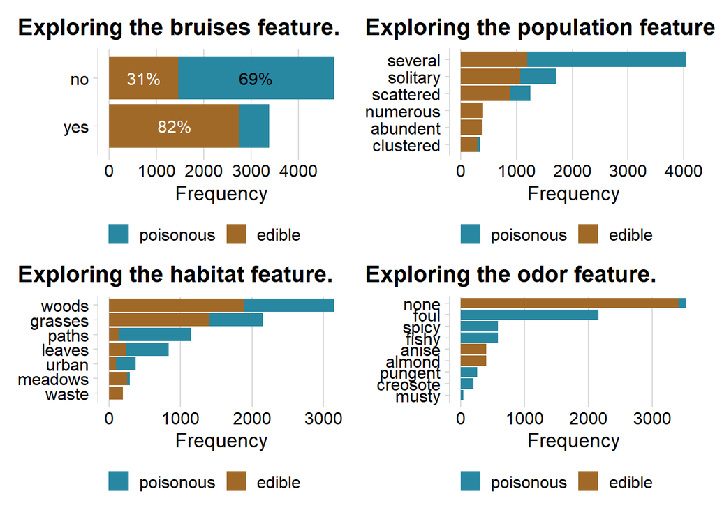

```r
plot_one_vars <- function(df, var){
  df %>%
    group_by(class, .data[[var]]) %>%
    summarise(prop_var_class = n()) %>%
    ungroup() %>%
    group_by(.data[[var]]) %>%
    mutate(prop_var = sum(prop_var_class)) %>%
    ungroup() %>%
    mutate(percent = prop_var_class / prop_var) %>%
    ggplot(aes(x = prop_var_class, y = fct_reorder(.data[[var]], prop_var),
               fill = class, label = percent %>%  percent(accuracy = 1))) +
    geom_col(position = 'stack') +
    geom_bar_text(position = "stack", place = 'center', reflow = TRUE, contrast = TRUE) +
    theme_minimal_vgrid() +
    theme(
      legend.position = "bottom",
      plot.title.position = "plot"
    ) +
    labs(
      title = paste("Exploring the", var, "feature."),
      x = 'Frequency',
      y = NULL
    ) +
    scale_fill_carto_d(name = NULL,
                           type = "diverging", palette = "Earth", direction = -1)
}

plot_one_vars(mushrooms_df, "bruises") +
  plot_one_vars(mushrooms_df, "population") +
  plot_one_vars(mushrooms_df, "habitat") +
  plot_one_vars(mushrooms_df, "odor")
```

### Interactions between variables

```r
plot_two_vars <- function(df, var, facet_var){
  df %>%
    group_by(class, .data[[var]], .data[[facet_var]]) %>%
    summarise(prop_var_class = n()) %>%
    ungroup() %>%
    group_by(.data[[var]]) %>%
    mutate(prop_var = sum(prop_var_class)) %>%
    ungroup() %>%
    ggplot(aes(x = prop_var_class, y = fct_reorder(.data[[var]], prop_var),
               fill = class)) +
    geom_col(position = 'stack') +
    facet_wrap(~.data[[facet_var]]) +
    theme_minimal_vgrid() +
    theme(
      legend.position = "bottom",
      plot.title.position = "plot"
    ) +
    labs(
      title = paste0("Exploring the ", var, " feature faceted by ", facet_var, "."),
      x = 'Frequency',
      y = NULL
    ) +
    scale_fill_carto_d(name = NULL,
                           type = "diverging", palette = "Earth", direction = -1)
}
```

### Interaction between odor and habitat

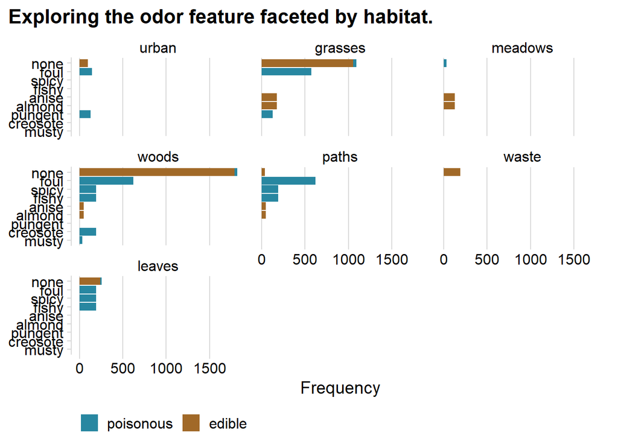

```r
plot_two_vars(mushrooms_df, "odor", "habitat")
```

### Interaction between bruises and odor

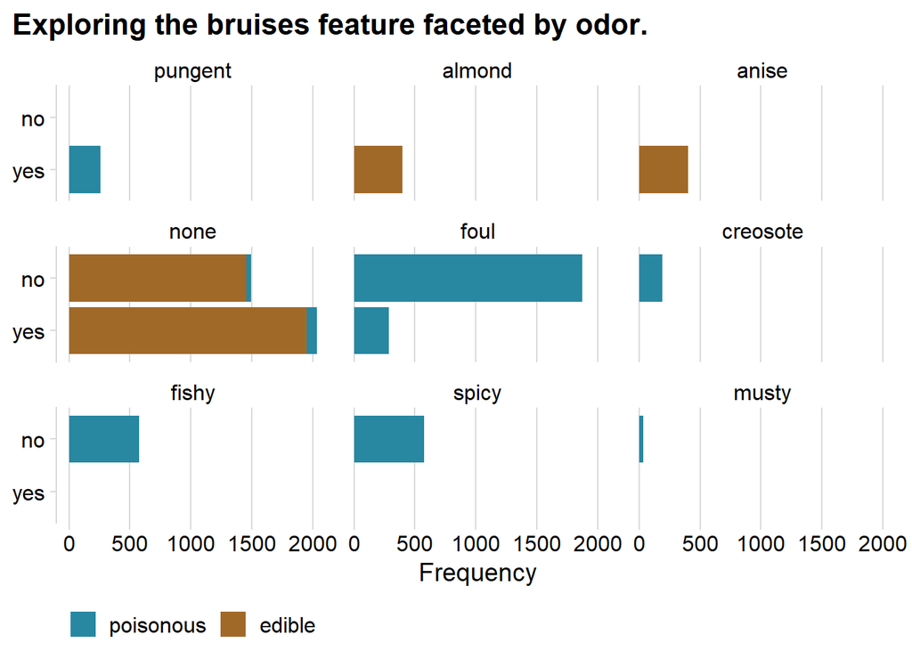

```r
plot_two_vars(mushrooms_df, "bruises", "odor")
```

### Interaction between habitat and population

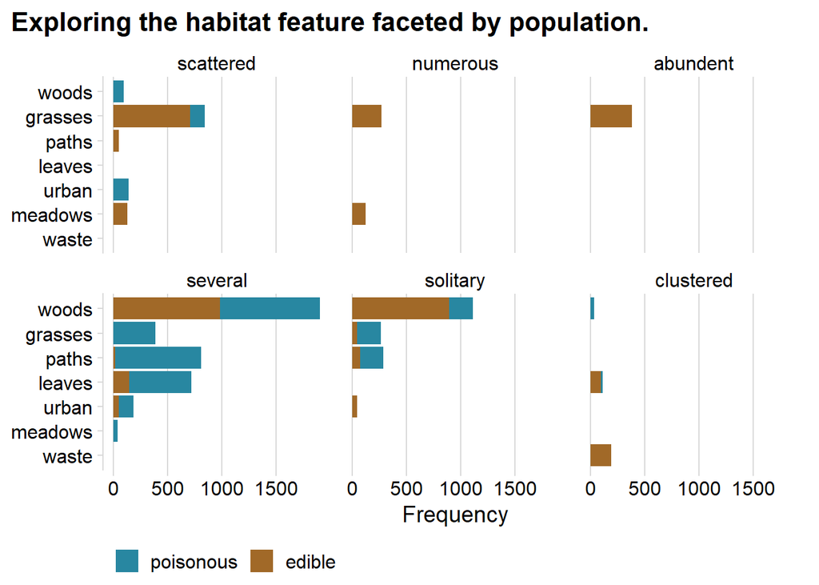

```r
plot_two_vars(mushrooms_df, "habitat", "population")
```

## Using Domain Knowledge

Using the articles [“How to Tell the Difference Between Poisonous and Edible Mushrooms”](https://www.wildfooduk.com/articles/how-to-tell-the-difference-between-poisonous-and-edible-mushrooms/)and [“How to identify Poisonous Mushrooms”](https://sciencing.com/identify-poisonous-mushrooms-2057768.html), we can find out which characteristics are common of poisonous and edible mushrooms. Let’s see if these rules are consistent with our data.

### Avoid mushrooms with red on the cap. Mushrooms with a red color on the cap are either poisonous or strongly hallucinogenic.

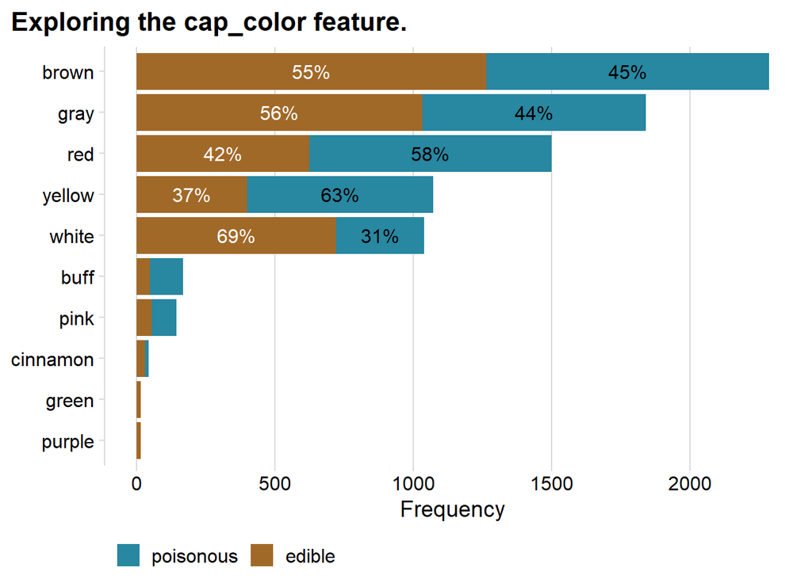

```r
plot_one_vars(mushrooms_df, "cap_color")
```

### You can also get information by cutting off the stem and placing the cap on a piece of paper gill-side down for a few hours to get a spore print. A white spore print is a telltale sign of an Amanita species.

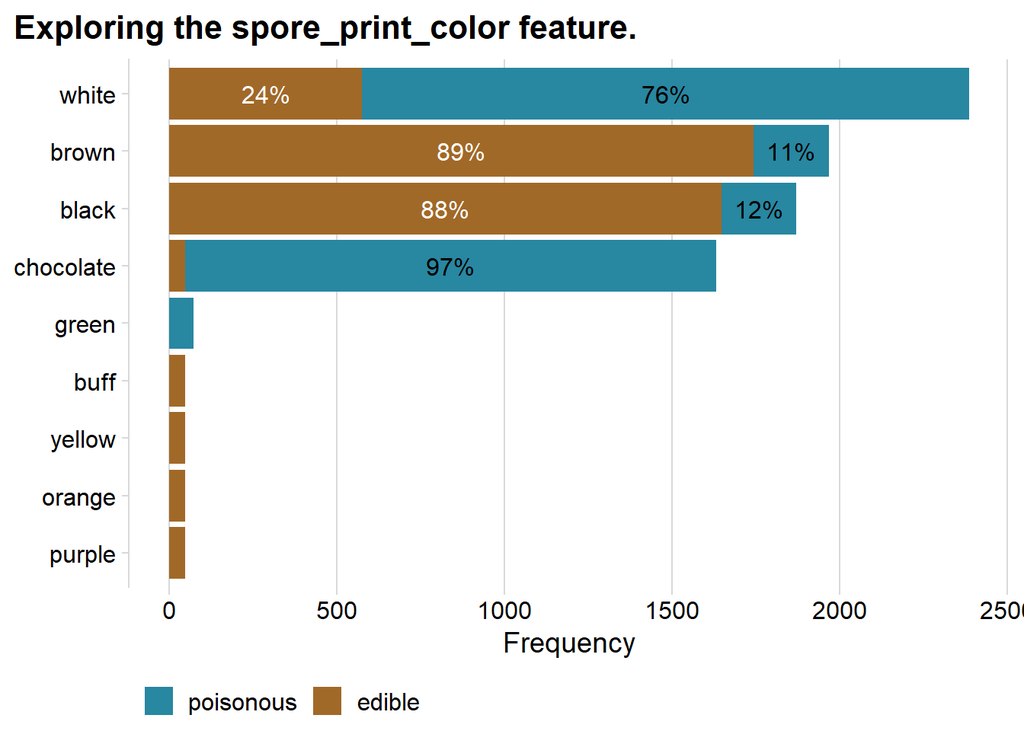

```r
plot_one_vars(mushrooms_df, "spore_print_color")
```

This rule is corresponds well with the data. we see that if the spore print color is white there is 76% chance of it being poisonous based on our data. It’as also interesting to see that if the color is brown or block there is a high chance of the mushroom being safe.

### Poisonous mushrooms often have an unpleasant, acrid smell, while benign ones smell refreshingly mushroomlike.

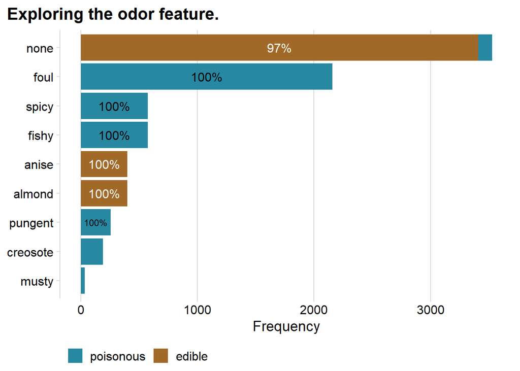

```r
plot_one_vars(mushrooms_df, "odor")
```

We’ve observed this before however its good to no that odor is a very strong characteristic for identifying poisonous mushrooms.

## Summary

Based on the EDA conducted I expect that bruises, odor, population, and spore print color will be strong features in predicting whether a mushroom is poisonous or edible. I think variables like habitat and cap color aren’t the strongest on their own but with an interaction of another variable may also be very informative. Keep in mind that I only looked at a third of the variables we have in the data. We can use model outputs to see which variables are important for classification.

# Building a model.

## Split the data for Bootstrapping

We split the data into training and testing so that we can validate the model we build against an independent sample of data. This allows us to avoid over-fitting the model and simulate trying to predict new data.

```r
set.seed(123)
mushrooms_split <- initial_split(mushrooms_df, strata = class)
mushrooms_train <- training(mushrooms_split)
mushrooms_test <- testing(mushrooms_split)

set.seed(234)
mushrooms_boot <- bootstraps(mushrooms_train)
```

## Define model and engine

```r
rf_spec <- rand_forest() %>%
  set_mode("classification") %>%
  set_engine("ranger", importance = "impurity")
```

## Define workflow

Here we define the workflow. Since we aren’t doing any pre-processing, the workflow is very short. The only thing we do here is tell the model that we are going to use all the variables to predict whether a mushroom is poisonous or edible.

```r
mushrooms_wf <- workflow() %>%
  add_formula(class ~ .)
```

## Run the model

Here we run the model using our training set with bootstrap resampling.

```r
rf_rs <- mushrooms_wf %>%
  add_model(rf_spec) %>%
  fit_resamples(
    resamples = mushrooms_boot,
    control = control_resamples(save_pred = TRUE, verbose = FALSE)
  )
```

## View Results

### View model parameters

```r
collect_metrics(rf_rs, summarize = TRUE)
```

```
## # A tibble: 2 × 6
##   .metric  .estimator  mean     n   std_err .config
##   <chr>    <chr>      <dbl> <int>     <dbl> <chr>
## 1 accuracy binary      1.00    25 0.0000362 Preprocessor1_Model1
## 2 roc_auc  binary      1       25 0         Preprocessor1_Model1
```

### View confusion matrix

```r
rf_rs %>%
  conf_mat_resampled()
```

```
## # A tibble: 4 × 3
##   Prediction Truth        Freq
##   <fct>      <fct>       <dbl>
## 1 poisonous  poisonous 1078.
## 2 poisonous  edible       0
## 3 edible     poisonous    0.08
## 4 edible     edible    1158.
```

### View ROC Curves

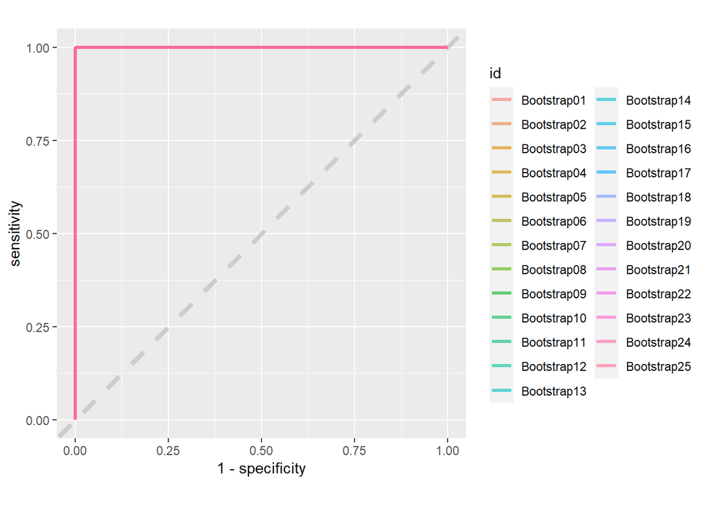

```r
rf_rs %>%
  collect_predictions() %>%
  group_by(id) %>%
  roc_curve(class, .pred_poisonous) %>%
  ggplot(aes(x = 1- specificity, y = sensitivity, color = id)) +
  geom_abline(lty = 2, color = 'grey80', size = 1.5) +
  geom_path(show.legend = T, alpha = 0.6, size = 1.2) +
  coord_equal()
```

### Run the model against the testing set

```r
mushrooms_final <- mushrooms_wf %>%
  add_model(rf_spec) %>%
  last_fit(mushrooms_split)

mushrooms_final$.workflow[[1]]
```

```
## ══ Workflow [trained] ══════════════════════════════════════════════════════════
## Preprocessor: Formula
## Model: rand_forest()
##
## ── Preprocessor ────────────────────────────────────────────────────────────────
## class ~ .
##
## ── Model ───────────────────────────────────────────────────────────────────────
## Ranger result
##
## Call:
##  ranger::ranger(x = maybe_data_frame(x), y = y, importance = ~"impurity",      num.threads = 1, verbose = FALSE, seed = sample.int(10^5,          1), probability = TRUE)
##
## Type:                             Probability estimation
## Number of trees:                  500
## Sample size:                      6093
## Number of independent variables:  22
## Mtry:                             4
## Target node size:                 10
## Variable importance mode:         impurity
## Splitrule:                        gini
## OOB prediction error (Brier s.):  0.0001810642
```

### Extract variable importance from final model

```r
extract_fit_parsnip(mushrooms_final$.workflow[[1]]) %>%
  vip::vi()
```

```
## # A tibble: 22 × 2
##    Variable                 Importance
##    <chr>                         <dbl>
##  1 odor                         1030.
##  2 spore_print_color             364.
##  3 gill_size                     233.
##  4 stalk_surface_above_ring      188.
##  5 ring_type                     171.
##  6 stalk_surface_below_ring      166.
##  7 bruises                       125.
##  8 stalk_root                    111.
##  9 gill_color                    105.
## 10 habitat                        85.3
## # ℹ 12 more rows
```

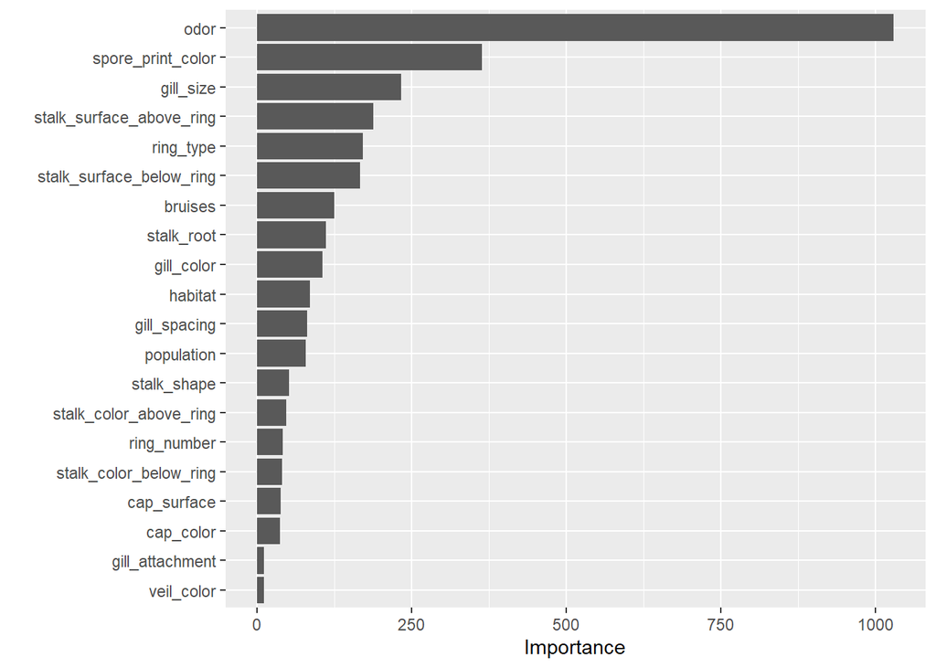

```r
mushrooms_final %>%
  extract_fit_parsnip() %>%
  vip::vip(num_features = 20)
```

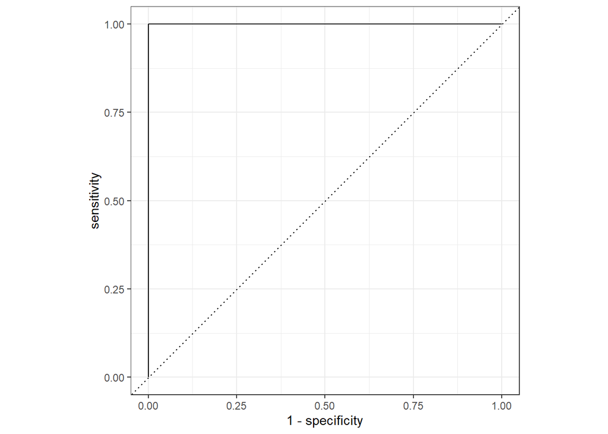

```r
mushrooms_final %>%
  collect_predictions() %>%
  roc_curve(class, .pred_poisonous) %>%
  autoplot()
```